# UNEP Emissions Gap Report 2026 - Chapter 2 Figures

UNEP Emissions Gap Report 2026 - Chapter 2 Figures

[William F. Lamb](https://lambwf.github.io/) | [Source Code](https://github.com/pik-ecs/UNEP-Gap-Report-2026-Chapter-2)

Each year the UN Environment Programme [Emissions Gap Report](https://www.unep.org/en/publications/report/emissions-gap-report-2026) provides an assessment of the state of progress towards the Paris Agreement. In chapter 2 of the report, we track global, national and sectoral greenhouse gas emissions trends. Here you can find a set of figures developed for the chapter.

The following underlying sources were used for the analysis:

- The EDGAR v2026 database of greenhouse gas emissions ([Crippa et al. 2025](https://edgar.jrc.ec.europa.eu/report_2026))
- The Global Carbon Budget database of historic CO2 emissions ([Friedlingstein et al. 2026](https://globalcarbonbudget.org/gcb-2025/))
- The National GHG Inventory Database of CO2 LULUCF emissions ([European Commission 2026](https://forest-observatory.ec.europa.eu/carbon/fluxes))
- The UNFCCC National Inventory Submissions ([Tidy GHG Inventories](https://lambwf.github.io/Tidy-GHG-Inventories/))

Please cite these sources as well as the [report](https://www.unep.org/en/publications/report/emissions-gap-report-2026) when using our figures.

Previous versions of this analysis can be found here:

- [UNEP Emissions Gap Report 2025](https://pik-ecs.github.io/UNEP-Gap-Report-2025-Chapter-2/)
- [UNEP Emissions Gap Report 2024](https://pik-ecs.github.io/UNEP-Gap-Report-2024-Chapter-2/)

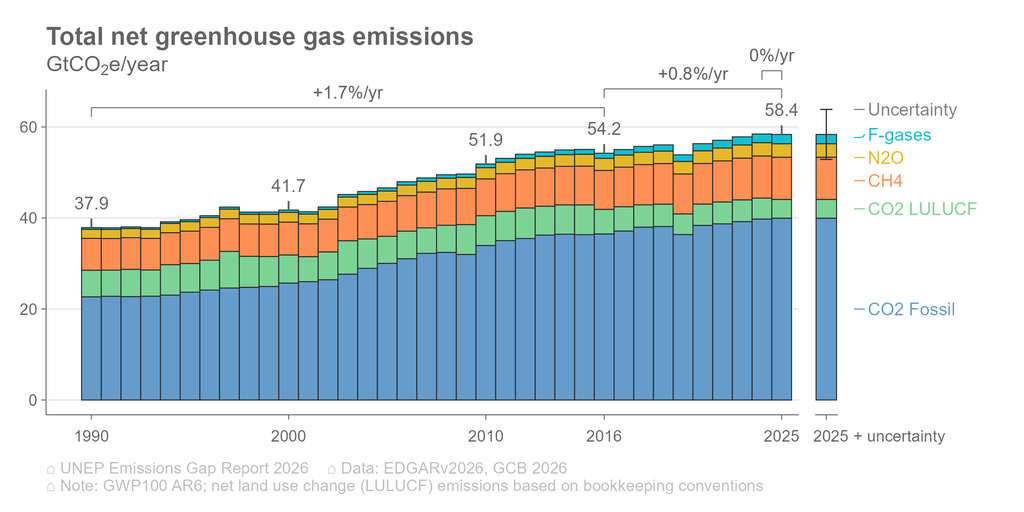

[data](https://github.com/pik-ecs/UNEP-Gap-Report-2026-Chapter-2/raw/main/results/standard/UNEP-EGR-2026-main-gas-trend.xlsx) | png | pdf | svg

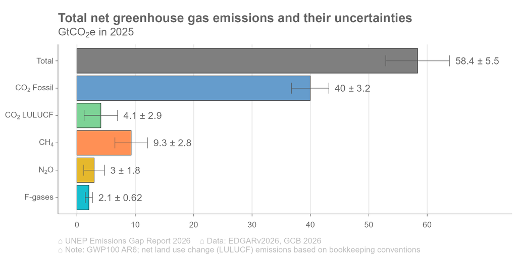

[data](https://github.com/pik-ecs/UNEP-Gap-Report-2026-Chapter-2/raw/main/results/standard/UNEP-EGR-2026-appendix-uncertainties.xlsx) | png | pdf | svg

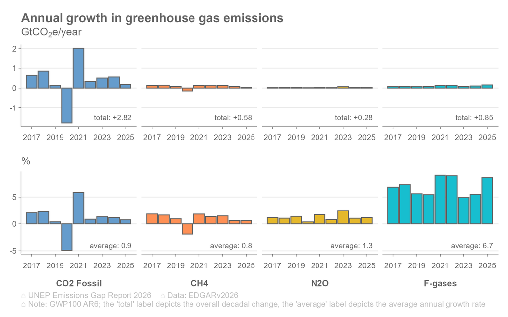

[data](https://github.com/pik-ecs/UNEP-Gap-Report-2026-Chapter-2/raw/main/results/standard/UNEP-EGR-2026-appendix-gas-growth.xlsx) | png | pdf | svg

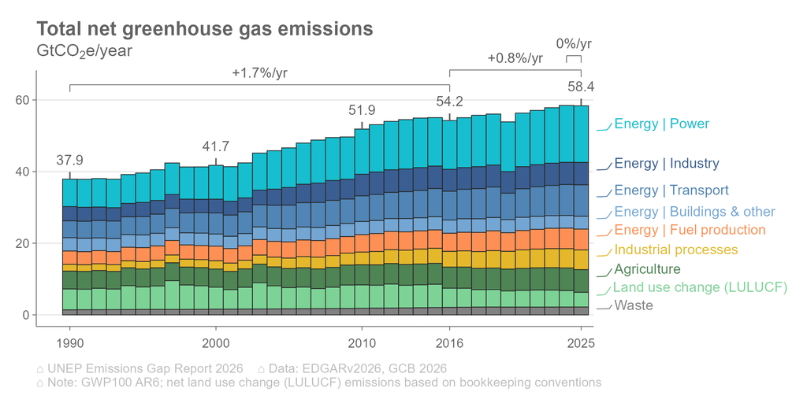

[data](https://github.com/pik-ecs/UNEP-Gap-Report-2026-Chapter-2/raw/main/results/standard/UNEP-EGR-2026-appendix-sector-trend.xlsx) | png | pdf | svg

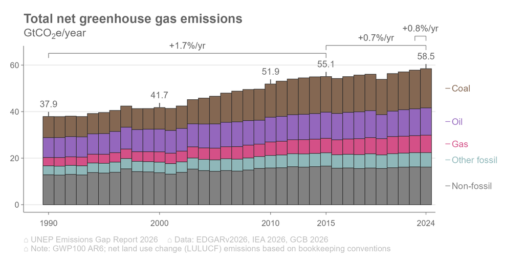

[data](https://github.com/pik-ecs/UNEP-Gap-Report-2026-Chapter-2/raw/main/results/standard/UNEP-EGR-2026-appendix-fossil-trend.xlsx) | png | pdf | svg

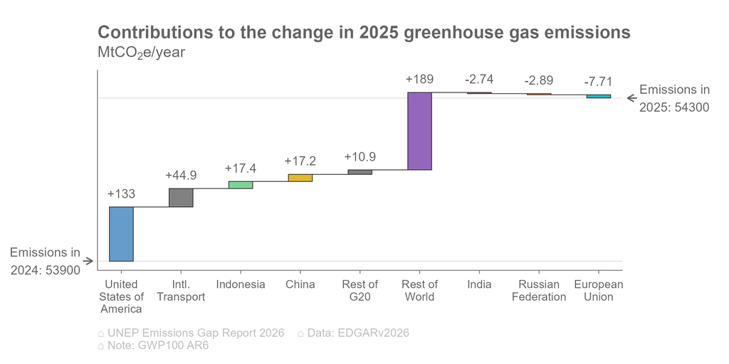

[data](https://github.com/pik-ecs/UNEP-Gap-Report-2026-Chapter-2/raw/main/results/standard/UNEP-EGR-2026-main-contributions-to-change.xlsx) | png | pdf | svg

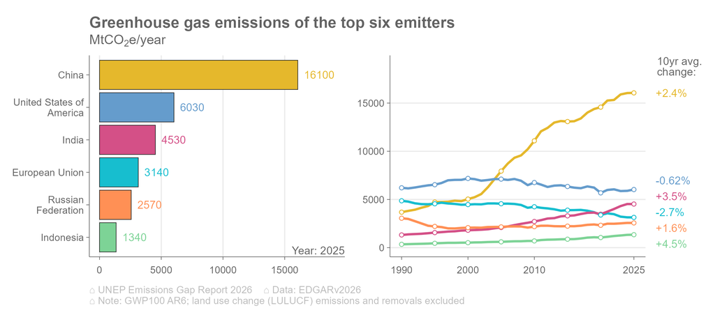

[data](https://github.com/pik-ecs/UNEP-Gap-Report-2026-Chapter-2/raw/main/results/standard/UNEP-EGR-2026-main-top-emitter-trend.xlsx) | png | pdf | svg

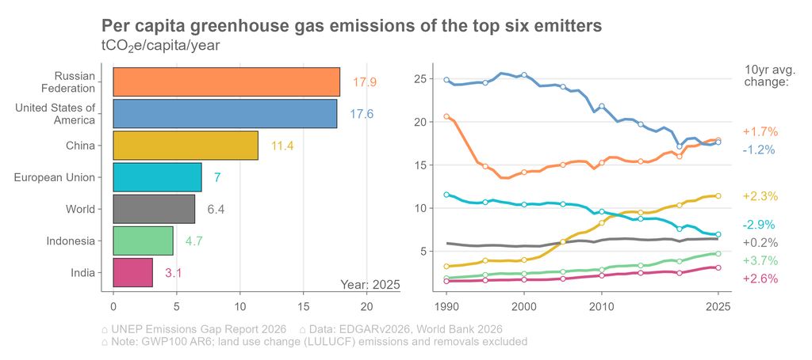

[data](https://github.com/pik-ecs/UNEP-Gap-Report-2026-Chapter-2/raw/main/results/standard/UNEP-EGR-2026-main-top-emitter-percapita.xlsx) | png | pdf | svg

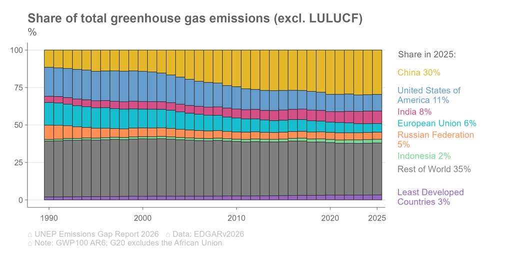

[data](https://github.com/pik-ecs/UNEP-Gap-Report-2026-Chapter-2/raw/main/results/standard/UNEP-EGR-2026-appendix-top-shares.xlsx) | png | pdf | svg

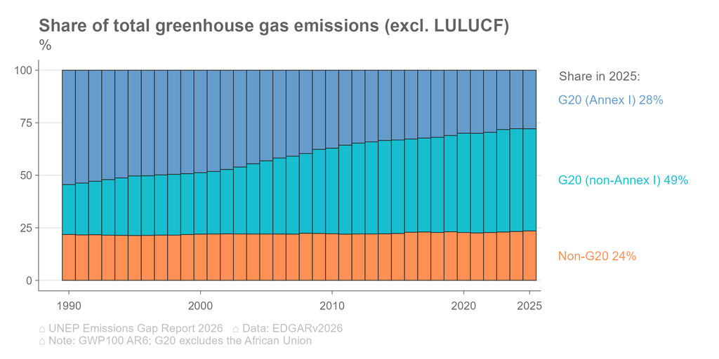

[data](https://github.com/pik-ecs/UNEP-Gap-Report-2026-Chapter-2/raw/main/results/standard/UNEP-EGR-2026-appendix-G20-shares.xlsx) | png | pdf | svg

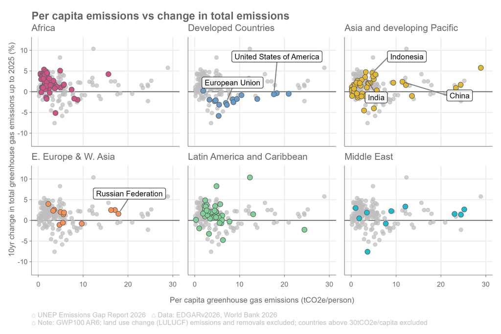

[data](https://github.com/pik-ecs/UNEP-Gap-Report-2026-Chapter-2/raw/main/results/standard/UNEP-EGR-2026-appendix-change-vs-percap.xlsx) | png | pdf | svg

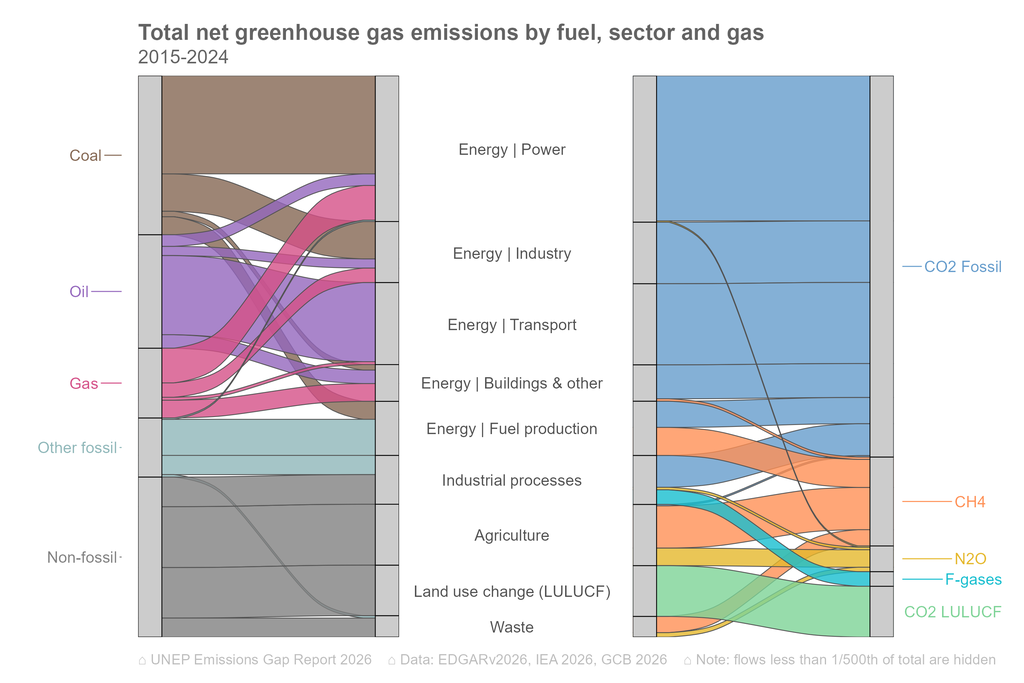

[data](https://github.com/pik-ecs/UNEP-Gap-Report-2026-Chapter-2/raw/main/results/standard/UNEP-EGR-2026-main-sankey.xlsx) | png | pdf | svg

# G20 country plots

(The data file for the plots below contains data for all countries)

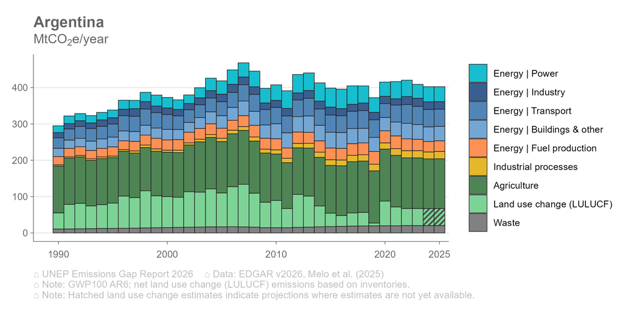

[data](https://github.com/pik-ecs/UNEP-Gap-Report-2026-Chapter-2/raw/main/results/standard/countries/UNEP-EGR-2026-country-trend.xlsx) | png | pdf | svg

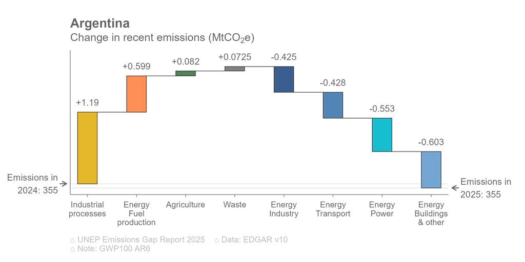

[data](https://github.com/pik-ecs/UNEP-Gap-Report-2026-Chapter-2/raw/main/results/standard/countries/UNEP-EGR-2026-country-change.xlsx) | png | pdf | svg

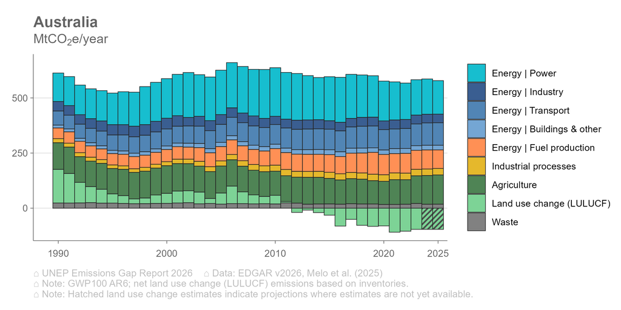

[data](https://github.com/pik-ecs/UNEP-Gap-Report-2026-Chapter-2/raw/main/results/standard/countries/UNEP-EGR-2026-country-trend.xlsx) | png | pdf | svg

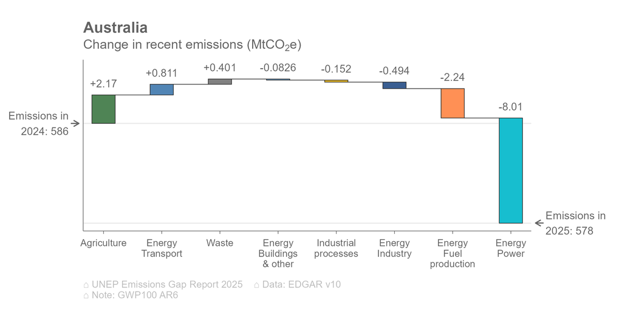

[data](https://github.com/pik-ecs/UNEP-Gap-Report-2026-Chapter-2/raw/main/results/standard/countries/UNEP-EGR-2026-country-change.xlsx) | png | pdf | svg

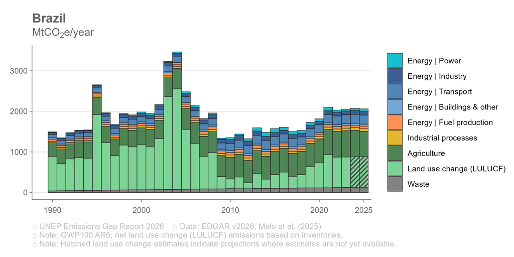

[data](https://github.com/pik-ecs/UNEP-Gap-Report-2026-Chapter-2/raw/main/results/standard/countries/UNEP-EGR-2026-country-trend.xlsx) | png | pdf | svg

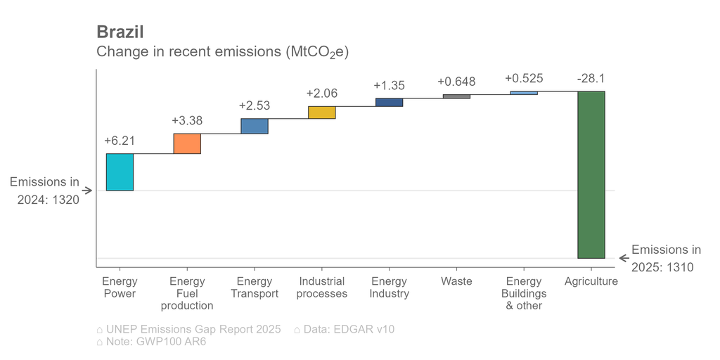

[data](https://github.com/pik-ecs/UNEP-Gap-Report-2026-Chapter-2/raw/main/results/standard/countries/UNEP-EGR-2026-country-change.xlsx) | png | pdf | svg

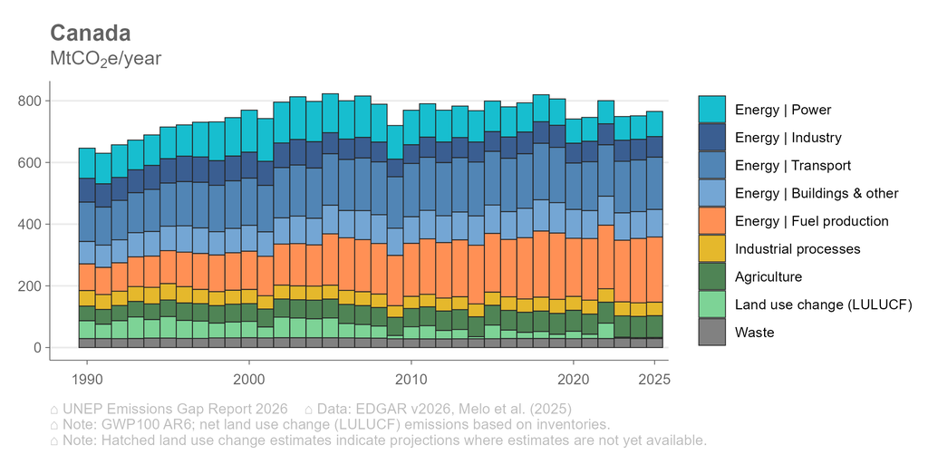

[data](https://github.com/pik-ecs/UNEP-Gap-Report-2026-Chapter-2/raw/main/results/standard/countries/UNEP-EGR-2026-country-trend.xlsx) | png | pdf | svg

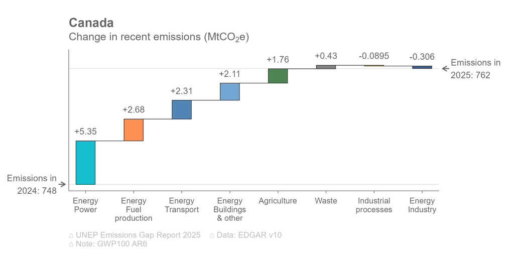

[data](https://github.com/pik-ecs/UNEP-Gap-Report-2026-Chapter-2/raw/main/results/standard/countries/UNEP-EGR-2026-country-change.xlsx) | png | pdf | svg

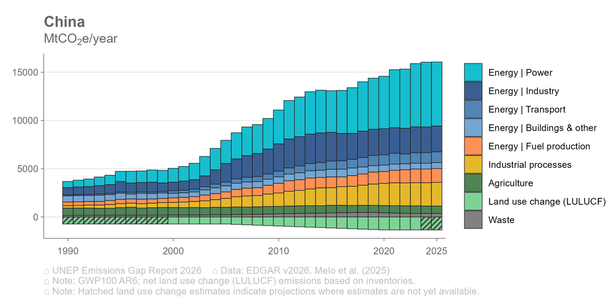

[data](https://github.com/pik-ecs/UNEP-Gap-Report-2026-Chapter-2/raw/main/results/standard/countries/UNEP-EGR-2026-country-trend.xlsx) | png | pdf | svg

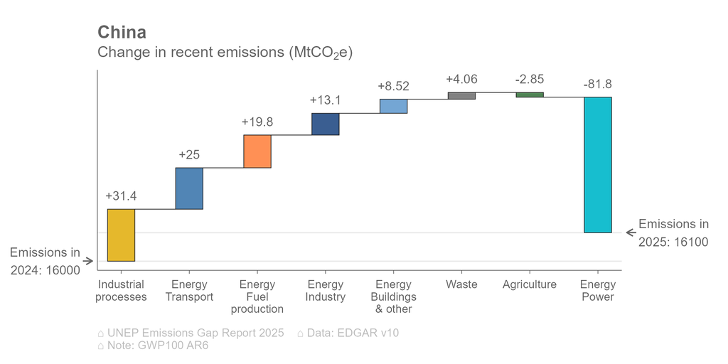

[data](https://github.com/pik-ecs/UNEP-Gap-Report-2026-Chapter-2/raw/main/results/standard/countries/UNEP-EGR-2026-country-change.xlsx) | png | pdf | svg

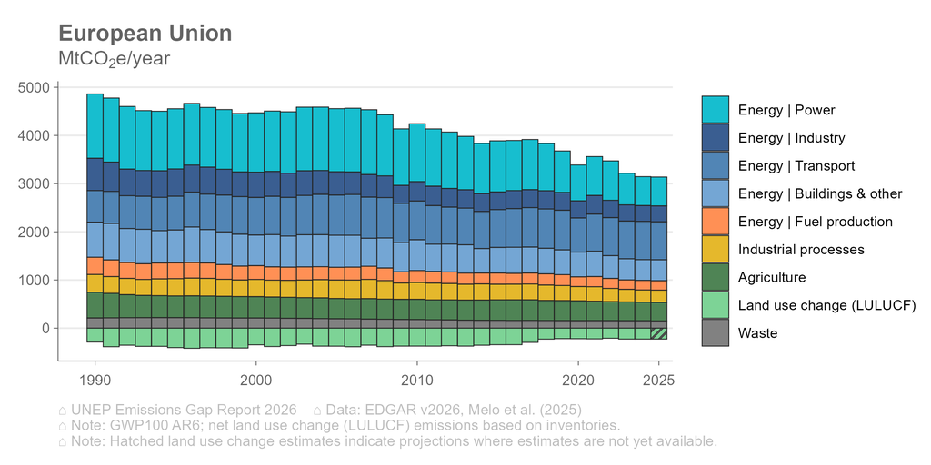

[data](https://github.com/pik-ecs/UNEP-Gap-Report-2026-Chapter-2/raw/main/results/standard/countries/UNEP-EGR-2026-country-trend.xlsx) | png | pdf | svg

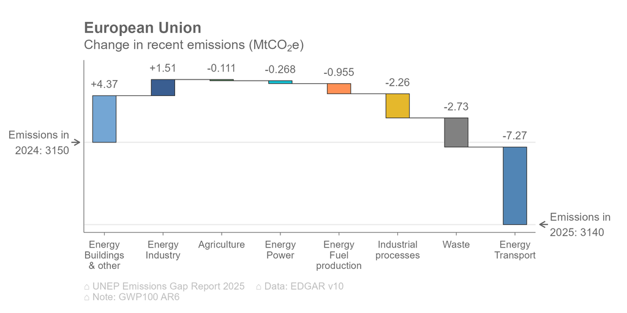

[data](https://github.com/pik-ecs/UNEP-Gap-Report-2026-Chapter-2/raw/main/results/standard/countries/UNEP-EGR-2026-country-change.xlsx) | png | pdf | svg

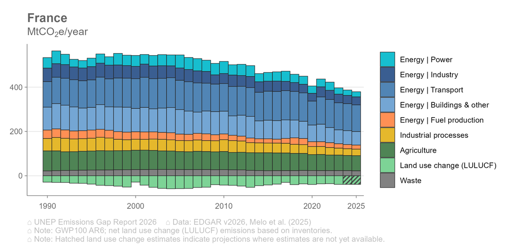

[data](https://github.com/pik-ecs/UNEP-Gap-Report-2026-Chapter-2/raw/main/results/standard/countries/UNEP-EGR-2026-country-trend.xlsx) | png | pdf | svg

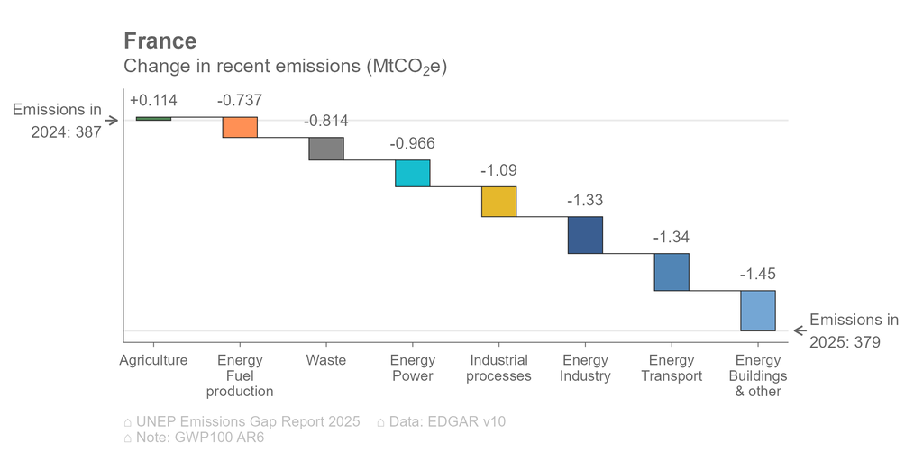

[data](https://github.com/pik-ecs/UNEP-Gap-Report-2026-Chapter-2/raw/main/results/standard/countries/UNEP-EGR-2026-country-change.xlsx) | png | pdf | svg

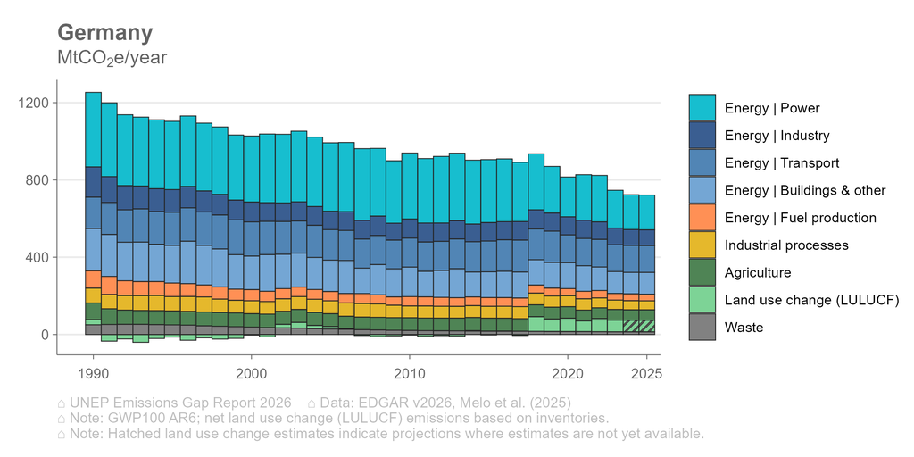

[data](https://github.com/pik-ecs/UNEP-Gap-Report-2026-Chapter-2/raw/main/results/standard/countries/UNEP-EGR-2026-country-trend.xlsx) | png | pdf | svg

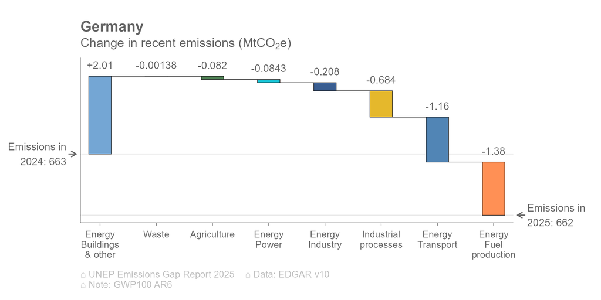

[data](https://github.com/pik-ecs/UNEP-Gap-Report-2026-Chapter-2/raw/main/results/standard/countries/UNEP-EGR-2026-country-change.xlsx) | png | pdf | svg

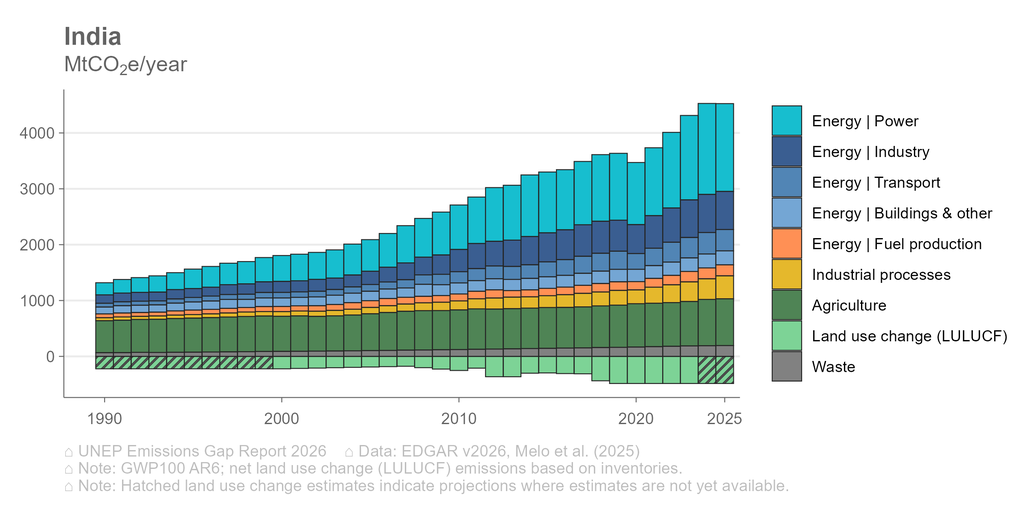

[data](https://github.com/pik-ecs/UNEP-Gap-Report-2026-Chapter-2/raw/main/results/standard/countries/UNEP-EGR-2026-country-trend.xlsx) | png | pdf | svg

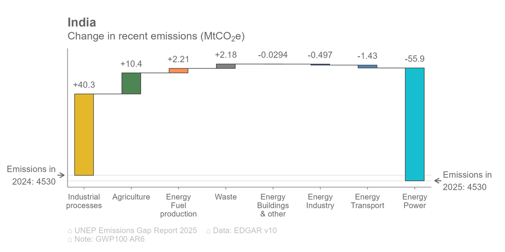

[data](https://github.com/pik-ecs/UNEP-Gap-Report-2026-Chapter-2/raw/main/results/standard/countries/UNEP-EGR-2026-country-change.xlsx) | png | pdf | svg

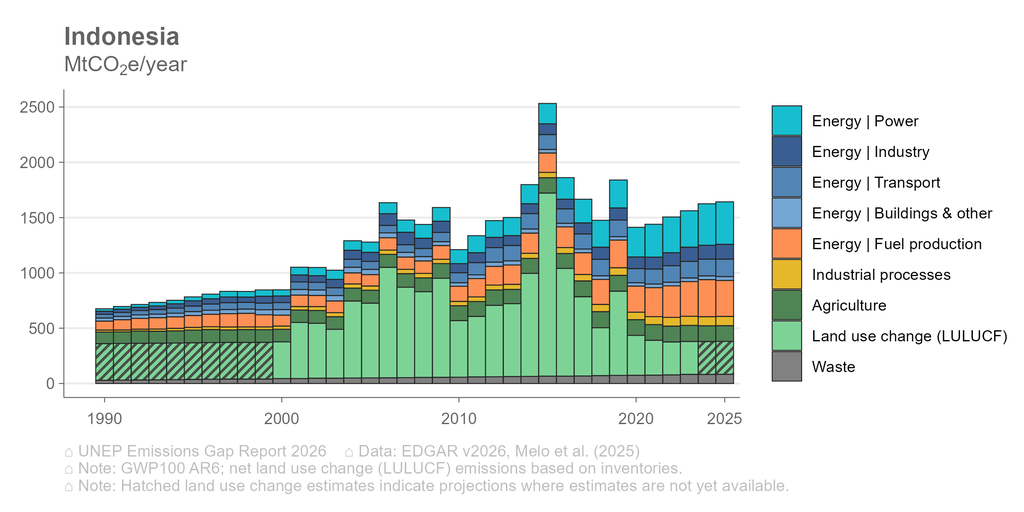

[data](https://github.com/pik-ecs/UNEP-Gap-Report-2026-Chapter-2/raw/main/results/standard/countries/UNEP-EGR-2026-country-trend.xlsx) | png | pdf | svg

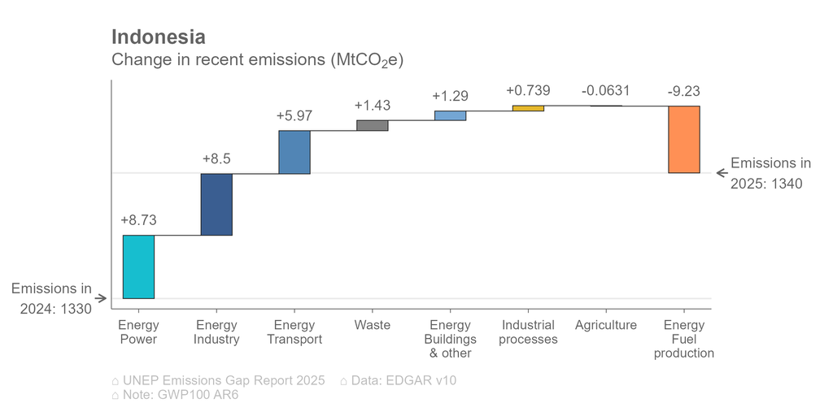

[data](https://github.com/pik-ecs/UNEP-Gap-Report-2026-Chapter-2/raw/main/results/standard/countries/UNEP-EGR-2026-country-change.xlsx) | png | pdf | svg